# CISER Statistics in R Workshop: Day 1

Presented by the Center for Interdisciplinary Statistical Education and Research

# Workshop Overview

- Day 1
  - Sample Size Calculations
  - Using R Data Frames
  - t-tests
- Day 2
  - Linear regression
  - Full/reduced drop tests
  - Reading data into R

# Sample Size Calculations in R

- Study to compare different solutions (A and B) for platelet storage in dogs
- Primary interest is to compare clumping of A to clumping of B
- Plan to analyze results using a t-test
- HOW DO I FIND OUT HOW TO ESTIMATE SAMPLE SIZES IN R?

# Extending the Functionality of R

- An R package is a collection of R functions, data, and compiled code in a well defined format
- Packages extend the base functionality of R

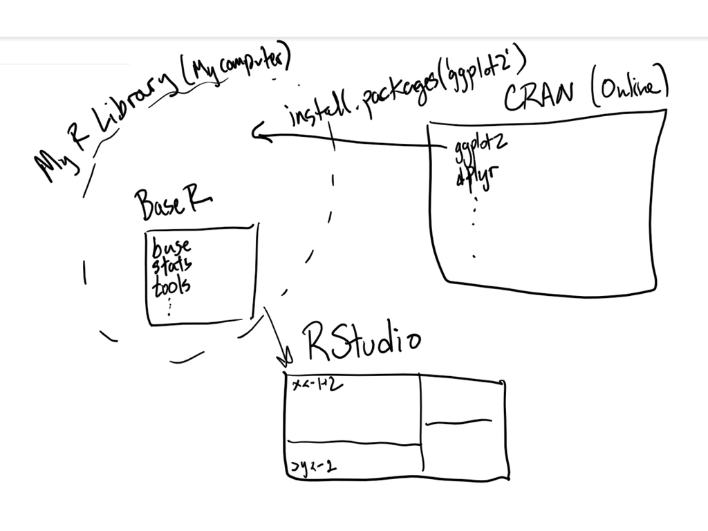

# Finding a Package for Sample Size Calculations

- Typically try:
  - CRAN Task Views: https://cran.r-project.org/web/views/
  - Google Search: “R power calculation”
- The `pwr` package in R can be used to make power calculations for some simple cases including
  - Tests for one or two normal populations
  - Tests for one or two proportions
- A package can be installed using the `install.packages()` function

```r
install.packages('pwr')
```

- Every time that you restart R and want to use the `pwr` package, run the following to make the functions available

```r
library(pwr)
```

- The `pwr.t.test` function can be used to make power calculations for 1-sample, 2-sample and paired t-tests

# Sample Size Calculations in R

- To make a sample size calculation, we need
  - alpha level = rate of being wrong under the null
  - power = rate of being right given model assumptions at the minimal significant difference
  - error standard deviation = expected deviation from treatment mean
  - minimal significant difference = the smallest difference we still want to be able to detect
- We want to make a power calculation for a one-sample t-test
- Assume this information is known
  - Type I error rate ($\alpha$) = 0.05
  - Type II error rate ($\beta$) = 0.20
  - error standard deviation = 1.25
  - difference in means = 0.6

# `pwr` package: t-test power calculations

- Requires entering
  - Effect Size: `d` = difference in means divided by estimated standard deviation
  - Type I Error Rate: `sig.level`
  - Power: `power` = 1 - Type II Error Rate
  - Type of t-test: `type` = `two.sample`, `one.sample`, `paired`
  - Alternative: `two.sided`, `greater`, `less`

```r
library(pwr)
pwr.t.test(d = 0.6 / 1.25, sig.level = 0.05, power = 0.80, type = "one.sample", alternative = "two.sided")
```

# `pwr` package: one-sample t-test power calculation

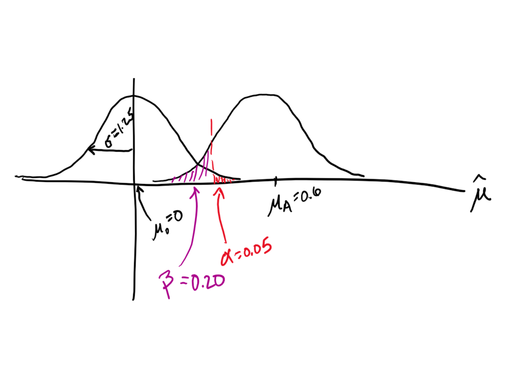

```r
library(pwr)
pwr.t.test(d = 0.6 / 1.25, sig.level = 0.05, power = 0.80, type = "one.sample", alternative = "two.sided")
```

```
##
##      One-sample t test power calculation
##
##               n = 36.03415
##               d = 0.48
##       sig.level = 0.05
##           power = 0.8
##     alternative = two.sided
```

# Exercise 1: Sample size for paired t-test

- Assume that a sample of cats are to undergo two separate treatments (trt A and trt B) for pain in randomized order
- Assume:
  - We plan on testing for differences between trt A and trt B with a paired t-test (equivalent to one-sample t-test on differences in pain)
  - Want to be able to detect an average difference in treatments of 0.75 or greater
  - Standard deviation of differences is 1.5
  - Want a power of 0.90 at an alpha value of 0.05

# Exercise 1 Solution

```r
pwr.t.test(d = 0.75 / 1.5, sig.level = 0.05, power = 0.90, type = "one.sample", alternative = "two.sided")
```

```
##
##      One-sample t test power calculation
##
##               n = 43.99548
##               d = 0.5
##       sig.level = 0.05
##           power = 0.9
##     alternative = two.sided
```

# Tooth Growth Dataset

ToothGrowth data set contains the result from an experiment studying the effect of vitamin C on tooth growth in 60 Guinea pigs. Each animal received one of three dose levels of vitamin C (0.5, 1, and 2 mg/day) by one of two delivery methods, (orange juice or ascorbic acid (a form of vitamin C and coded as VC).

- The `head` function returns the first or last parts of a vector, matrix, table, data frame or function
- The `head` function is useful in getting a quick sense of what your data look like

```r
head(ToothGrowth)
```

```
##    len supp dose
## 1  4.2   VC  0.5
## 2 11.5   VC  0.5
## 3  7.3   VC  0.5
## 4  5.8   VC  0.5
## 5  6.4   VC  0.5
## 6 10.0   VC  0.5
```

# data.frames for working with data of multiple types in R

- data.frames allow for row / column subsetting of multi-class data
- ToothGrowth is a data.frame
- We can verify this using the `class` function

```r
class(ToothGrowth)
```

```
## [1] "data.frame"
```

- The class function is very helpful in identifying whether variables are of the appropriate class before we conduct an analysis
- We can check the class of variable in the ToothGrowth data.frame

```r
class(ToothGrowth$len)
```

```
## [1] "numeric"
```

- Placing the `$` after a data.frame will allow us to access particular variables in the data.frame

```r
ToothGrowth$len
```

```
##  [1]  4.2 11.5  7.3  5.8  6.4 10.0 11.2 11.2  5.2  7.0 16.5 16.5 15.2 17.3
## [15] 22.5 17.3 13.6 14.5 18.8 15.5 23.6 18.5 33.9 25.5 26.4 32.5 26.7 21.5
## [29] 23.3 29.5 15.2 21.5 17.6  9.7 14.5 10.0  8.2  9.4 16.5  9.7 19.7 23.3
## [43] 23.6 26.4 20.0 25.2 25.8 21.2 14.5 27.3 25.5 26.4 22.4 24.5 24.8 30.9
## [57] 26.4 27.3 29.4 23.0
```

# Exercise 2: Determine classes of variables

- Determine the class of `supp` and `dose` from the ToothGrowth data

# Exercise 2 Solution

- The class of the `supp` variable is a factor and the class of the `dose` variable is numeric
- Factors are also called categorical variables

```r
class(ToothGrowth$supp)
```

```
## [1] "factor"
```

```r
class(ToothGrowth$dose)
```

```
## [1] "numeric"
```

# Creating simple data.frames directly in R

```r
df <- data.frame(
  a = c(1, 2, 3),
  b = c("x", "y", "z"),
  c = c(TRUE, TRUE, FALSE),
  d = factor(c("cat", "dog", "horse"))
  )
```

# Taking subsets of rows / columns

```r
# Extracting a single row
df[3, ]
```

```
##   a b     c     d
## 3 3 z FALSE horse
```

```r
# Extracting a single column
df[, 2]
```

```
## [1] x y z
## Levels: x y z
```

```r
# Extracting multiple rows
df[c(1,3), ]
```

```
##   a b     c     d
## 1 1 x  TRUE   cat
## 3 3 z FALSE horse
```

```r
# Extracting multiple columns
df[, c(2,3)]
```

```
##   b     c
## 1 x  TRUE
## 2 y  TRUE
## 3 z FALSE
```

```r
# Removing rows
df[-c(2,3), ]
```

```
##   a b    c   d
## 1 1 x TRUE cat
```

```r
# Removing columns
df[, -3]
```

```
##   a b     d
## 1 1 x   cat
## 2 2 y   dog
## 3 3 z horse
```

```r
# Extracting a column by name
df[, c("a", "c")]
```

```
##   a     c
## 1 1  TRUE
## 2 2  TRUE
## 3 3 FALSE
```

```r
df$a
```

```
## [1] 1 2 3
```

```r
# Returning rows that meeting only a certain criteria
df[df$c == TRUE & df$a >1, ]
```

```
##   a b    c   d
## 2 2 y TRUE dog
```

# Exercise 3: Subsetting the ToothGrowth data

- Imagine we want to compare tooth growth for vitamin C doses of 0.5 and 2 mg per day with a delivery method of orange juice ignoring all of the other collected data
- Extract the lengths separately for the orange juice 0.5 mg/day group and the orange juice 2.0mg/day group

# Exercise 3 Solution

```r
len05 <- ToothGrowth[ToothGrowth$dose == 0.5 & ToothGrowth$supp == "OJ",]$len
len20 <- ToothGrowth[ToothGrowth$dose == 2.0 & ToothGrowth$supp == "OJ",]$len
```

# t-test for the ToothGrowth Data

- A t-test can be run in R using the function `t.test`
- For instance, lets say that we wanted to run a t-test to test for a difference between the 0.5 mg/day and the 2.0mg/day orange juice groups from the ToothGrowth data.

```r
# Conduct a two sample, two-sided Welch's t-test
t.test(len20, len05)
```

```
##
##  Welch Two Sample t-test
##
## data:  len20 and len05
## t = 7.817, df = 14.668, p-value = 1.324e-06
## alternative hypothesis: true difference in means is not equal to 0
## 95 percent confidence interval:
##   9.324759 16.335241
## sample estimates:
## mean of x mean of y
##     26.06     13.23
```

- Running the `t.test` function prints out a few helpful pieces of information including
  - The t-statistic
  - The error degrees of freedom
  - The p-value
  - 95 % confidence intervals on the estimated difference in means
  - Sample means for the two groups

# Options for the `t.test` function

- We can browse the `t.test` options by typing

```r
?t.test
```

- Some of the most useful options are:
  - `alternative`: Run a 1-sided t-test
  - `paired`: Conducting paired t-tests
  - `var.equal`: Conducting equal variance t-tests
- To conduct a one sample t-test to test the null hypothesis that the mean length for the 0.5 mg/day group was >= 15

```r
t.test(len05, mu = 15, alternative = "less")
```

```
##
##  One Sample t-test
##
## data:  len05
## t = -1.2551, df = 9, p-value = 0.1205
## alternative hypothesis: true mean is less than 15
## 95 percent confidence interval:
##      -Inf 15.81521
## sample estimates:
## mean of x
##     13.23
```

# Exercise 4: T-tests

- Conduct a one-sided t-test to test the null hypothesis that the mean length for the 2.0 mg/day group is <= 24

# Exercise 4 Solution

```r
t.test(len20, mu = 24, alternative = "greater")
```

```
##
##  One Sample t-test
##
## data:  len20
## t = 2.4535, df = 9, p-value = 0.01827
## alternative hypothesis: true mean is greater than 24
## 95 percent confidence interval:
##  24.52091      Inf
## sample estimates:
## mean of x
##     26.06
```